# Clustering_R_records

Cholian Li (Chao Li) cl1486

10/11/2021

# Introduction

Data sources: Crypto_quotes_with_change_label.csv

Test data: test_records.csv

```r
library(proxy)
library(factoextra) # for fviz
library("amap")
library('purrr')
```

```r
setwd('C:/Users/Cholian/OneDrive/GU/Semester1/ANLY-501-04/portfolio/Project draft/clustering/clustering/R on records')

options(warn = -1)
```

## Data description

The dataset has 86 rows and 18 columns. Each column of this dataset is composed of multiple financial indicators. For example, The column “MACD” is calculated by collecting the previous three months’ data and up to Sept.30.

Each row represents different tokens. For example, BTCUSDT is one of the famous crypto tokens.

Beyond that, test data is randomly selected from the whole dataset to test the clustering performance

```r
ori_data <-  read.csv('Crypto_quotes_with_change_label.csv',encoding = 'utf8',row.names = 'token')

# seperate the in-sample and out-of-sample data
test_index <- sample(1:nrow(ori_data), 3)
data <- ori_data[-test_index,]
test_data <- ori_data[test_index,]

ncol(ori_data)
```

```
## [1] 18
```

```r
nrow(ori_data)
```

```
## [1] 86
```

```r
nrow(data)
```

```
## [1] 83
```

```r
data[1:5,1:5]
```

```
##         BBANDS_upperband BBANDS_middleband BBANDS_lowerband      DEMA       EMA
## BTCUSDT       0.36232208         0.3619921        0.3671333 0.6497957 0.4766027
## ETHUSDT       0.48959405         0.5110838        0.5027089 0.6533452 0.8261049
## BNBUSDT       0.22941396         0.1922042        0.2239521 0.4315577 0.3186039
## NEOUSDT       0.09416549         0.1073517        0.1240704 0.3871186 0.1825925
## LTCUSDT       0.10787278         0.1267312        0.1467526 0.4650391 0.1978597
```

# EDA & Data cleaning

All the data is numeric and there are four labels as following explanation

**Down:** price change down to -15% and lower

**Steady：**price change goes around from -15% to +15%

**Up:** price change goes up to 15%-25%

**Crazy rise:** price change goes up to 25% or higher

```r
str(data)
```

```
## 'data.frame':    83 obs. of  18 variables:
##  $ BBANDS_upperband : num  0.3623 0.4896 0.2294 0.0942 0.1079 ...
##  $ BBANDS_middleband: num  0.362 0.511 0.192 0.107 0.127 ...
##  $ BBANDS_lowerband : num  0.367 0.503 0.224 0.124 0.147 ...
##  $ DEMA             : num  0.65 0.653 0.432 0.387 0.465 ...
##  $ EMA              : num  0.477 0.826 0.319 0.183 0.198 ...
##  $ HT_TRENDLINE     : num  0.684 0.705 0.492 0.293 0.355 ...
##  $ macd             : num  0.491 0.142 0.365 0.298 0.345 ...
##  $ macdsignal       : num  0.494 0.165 0.317 0.266 0.367 ...
##  $ macdhist         : num  0.506 0.608 0.767 0.721 0.661 ...
##  $ mfi              : num  0.4 0.331 0.348 0.253 0.16 ...
##  $ willr            : num  0.439 0.358 0.634 0.23 0.262 ...
##  $ ad               : num  0.952 0.969 0.996 0.943 0.675 ...
##  $ adosc            : num  0.481 0.258 0.394 0.139 0.311 ...
##  $ obv              : num  0.3661 0.8067 0.3589 0.7544 0.0396 ...
##  $ atr              : num  0.214 0.326 0.172 0.097 0.14 ...
##  $ natr             : num  0.1782 0.1843 0.0914 0.1135 0.1342 ...
##  $ trange           : num  0.1516 0.1063 0.0527 0.0232 0.0416 ...
##  $ Quotes_label     : chr  "Steady" "Steady" "Down" "Down" ...
```

```r
# feature
data_x <- data[,1:ncol(data)-1]

# missing values
data_x[is.na(data_x)] <- 0

data_x_norm <- as.data.frame(apply(data_x, 2, ##2 for col
                                 function(x) (x - min(x))/(max(x)-min(x))))

# label
data_y <- data[,ncol(data)]
data_y[is.na(data_y)]
```

```
## character(0)
```

```r
# check the types of labels
table(data_y)
```

```
## data_y
## Crazy rise       Down     Steady         Up
##          3         49         21         10
```

# Clustering

## Distance Matrix

To show the relationship between different tokens’ financial indicators, various distance matrix should be calculated to show that.

Findings :

1. There is a distinct relationship clustering pattern between different tokens.

For example, under the Manhattan distance matrix, tokens ranked before 34 are highly related to remainings. Besides that, tokens ranked in the head are generally tokens with large market value, like BTCUSDT, BNBUSDT, ETHUSDT. With the first glance at the relationship, it can be assumed to say that all the tokens can be divided into two parts: large tokens and small tokens.

2. Other distance matrices like the Euclidean and cosine show thee similar patter.

The above glance on the distance matrix gives a start clustering centers on k = 2 or 3.

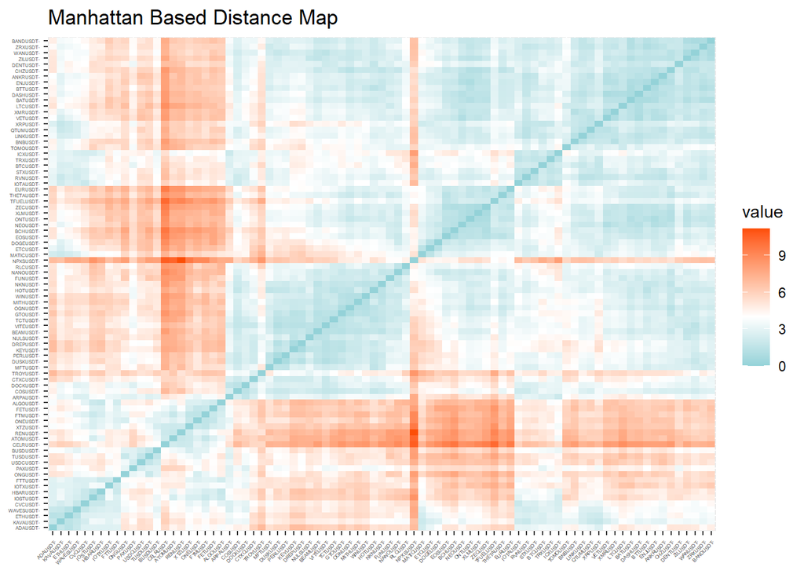

```r
Dist_M<- proxy::dist(data_x, method = "Manhattan") ##Manhattan
fviz_dist(Dist_M, gradient = list(low = "#00AFBB",
                                     mid = "white", high = "#FC4E07"))+
  ggtitle("Manhattan Based Distance Map")+theme(axis.text = element_text(size=3))
```

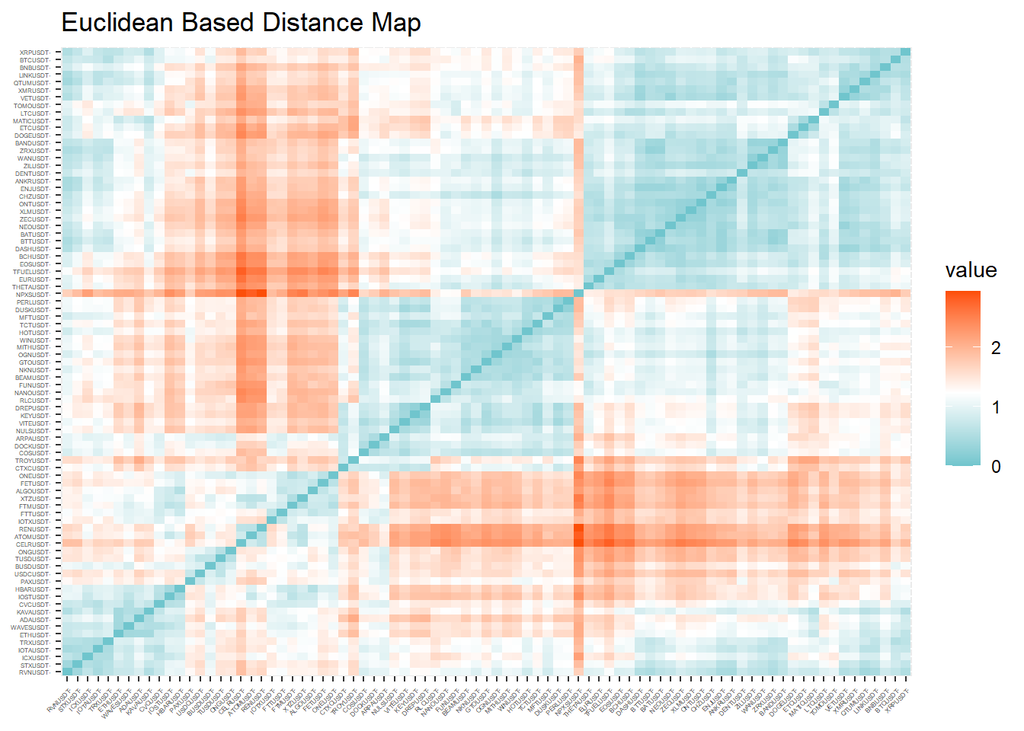

```r
Dist_E<- proxy::dist(data_x, method = "Euclidean") #Euclidean
fviz_dist(Dist_E, gradient = list(low = "#00AFBB",
                                     mid = "white", high = "#FC4E07"))+
  ggtitle("Euclidean Based Distance Map")+theme(axis.text = element_text(size=3))
```

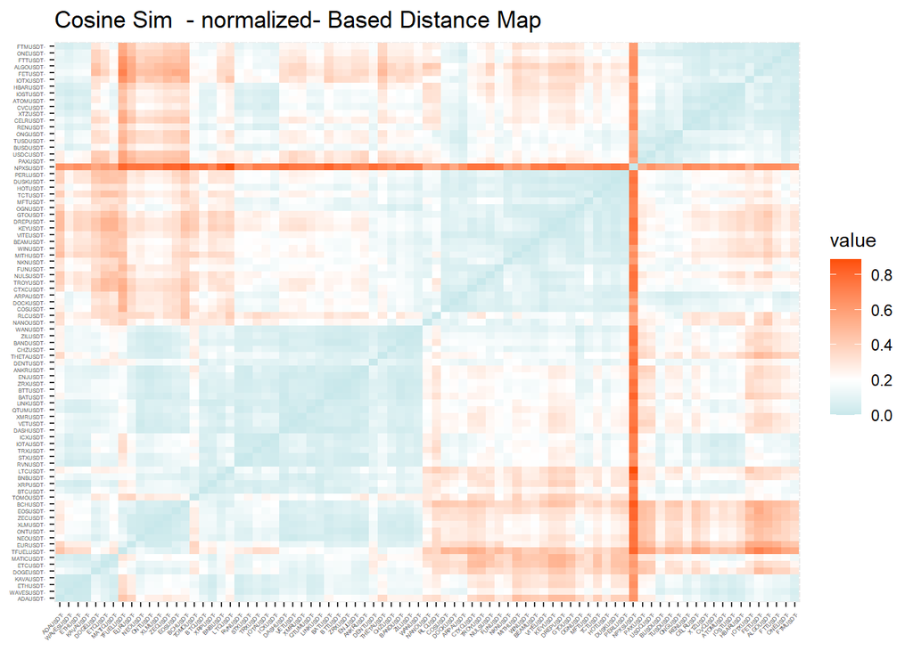

```r
Dist_C <- proxy::dist(data_x, method="cosine") # Cosine
fviz_dist(Dist_C, gradient = list(low = "#00AFBB",
                                     mid = "white", high = "#FC4E07"))+
  ggtitle("Cosine Sim  - normalized- Based Distance Map")+theme(axis.text = element_text(size=3))
```

## K-means

### Clusters optimization

Choosing the number of centers is a hard task.

#### NbClust

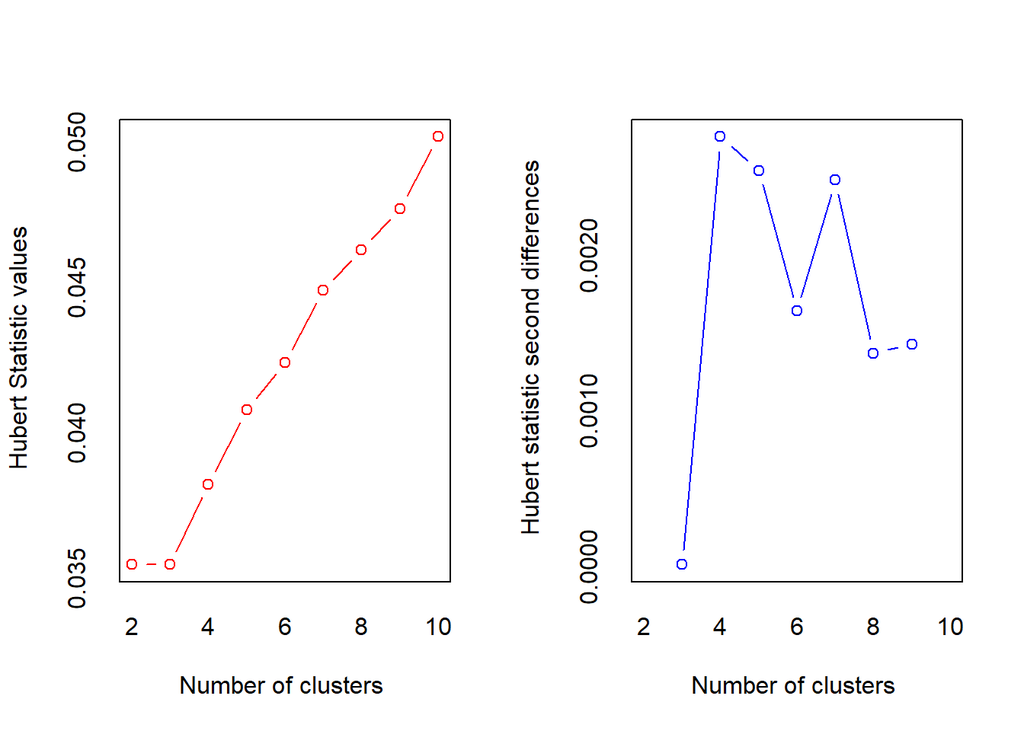

```
## *** : The Hubert index is a graphical method of determining the number of clusters.
##                 In the plot of Hubert index, we seek a significant knee that corresponds to a
##                 significant increase of the value of the measure i.e the significant peak in Hubert
##                 index second differences plot.
##
```

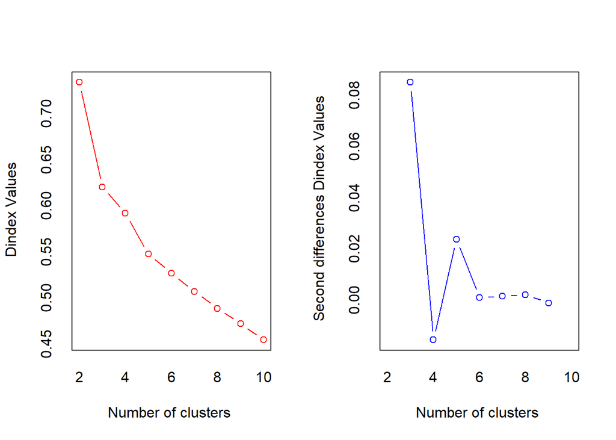

```
## *** : The D index is a graphical method of determining the number of clusters.
##                 In the plot of D index, we seek a significant knee (the significant peak in Dindex
##                 second differences plot) that corresponds to a significant increase of the value of
##                 the measure.
##
## * Among all indices:
## * 3 proposed 2 as the best number of clusters
## * 12 proposed 3 as the best number of clusters
## * 2 proposed 4 as the best number of clusters
## * 1 proposed 6 as the best number of clusters
## * 2 proposed 7 as the best number of clusters
## * 1 proposed 8 as the best number of clusters
## * 2 proposed 10 as the best number of clusters
##
##                    ***** Conclusion *****
##
## * According to the majority rule, the best number of clusters is  3
##
##
```

```r
# png('K-means_clusters.png')
kmeans_crypto<-NbClust::NbClust(data_x,
                              min.nc=2, max.nc=10, method="kmeans")
```

```r
# dev.off()

## How many clusters is best....let's SEE.........
table(kmeans_crypto$Best.n[1,])
```

```
##
##  0  1  2  3  4  6  7  8 10
##  2  1  3 12  2  1  2  1  2
```

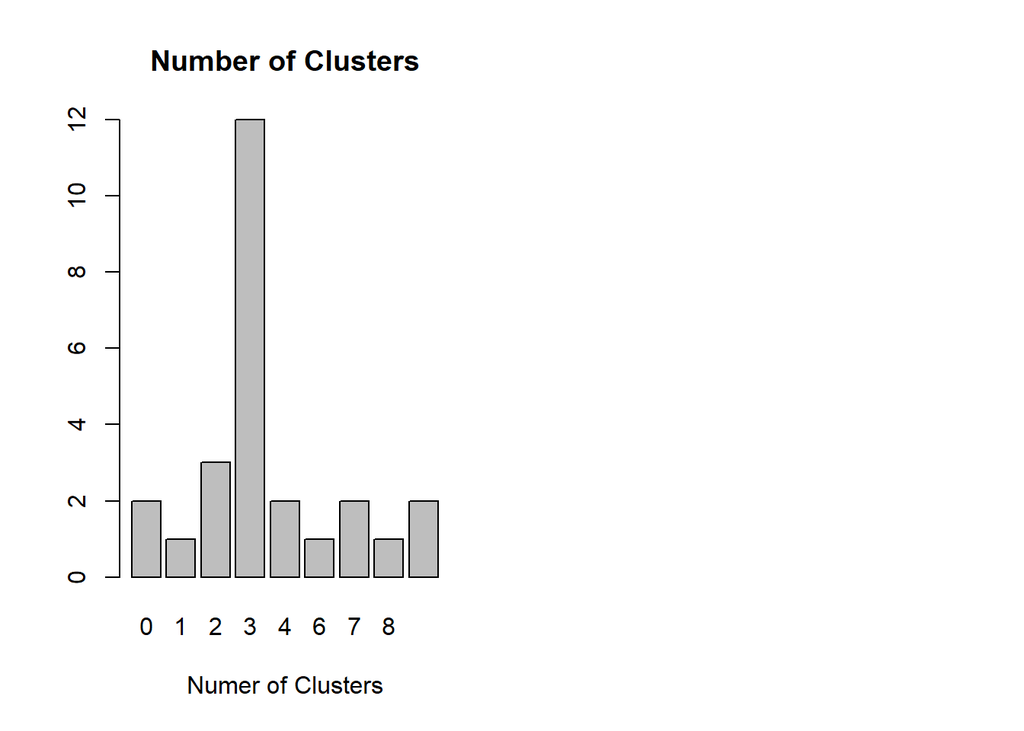

```r
barplot(table(kmeans_crypto$Best.n[1,]),
        xlab="Numer of Clusters", ylab="",
        main="Number of Clusters")
```

#### Silhouette

However, the Silhouette test show a different suggestion on k, which should be 2.

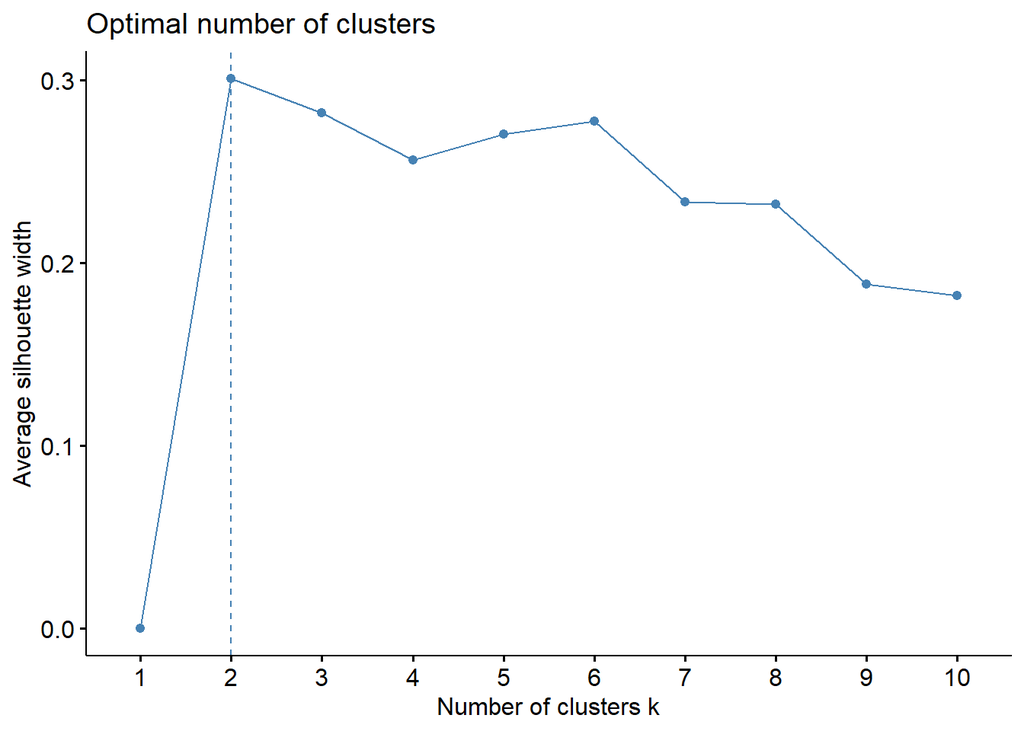

```r
fviz_nbclust(data_x, method = "silhouette",
                      FUN = hcut, k.max = 10)
```

#### Elbow method

The elbow method did not provide any useful information on the choice of k, except that there is also a slight elbow around k=3 or 4.

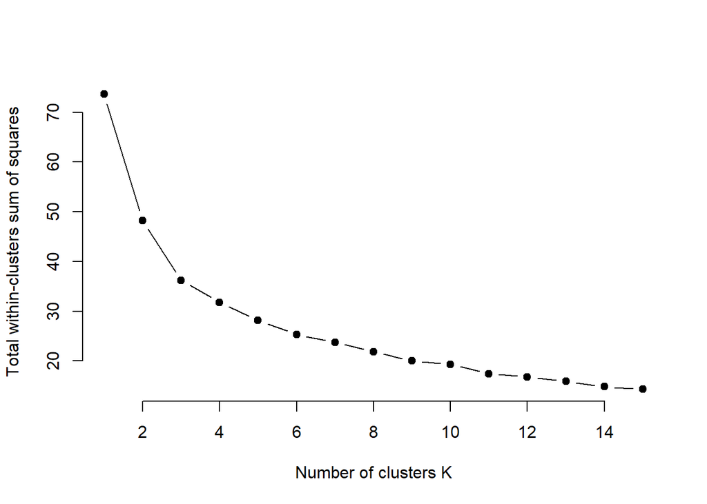

```r
set.seed(123)

# functiodata_xuster sum of square
wss <- function(k) {
  kmeans(data_x, k, nstart = 10 )$tot.withinss
}

# Compute and plot wss for k = 1 to k = 15
k.values <- 1:15

# extract wss for 2-15 clusters
wss_values <- map_dbl(k.values, wss)

plot(k.values, wss_values,
       type="b", pch = 19, frame = FALSE,
       xlab="Number of clusters K",
       ylab="Total within-clusters sum of squares")
```

## Clustering

The following series of clustering with different options on k provide a clearer understanding of the clustering result.

FIndings:

1. The clustering using “Spearman” method performed a bit worse than using “Euclidean” method.

For example, with “Spearman” method of k from 2 to 5, there are always over-lap between different clustering. Compared that with “Spearman”, the “Euclidean” method provides a better boundary between different clusters.

2. When k = 3, the clustering result show a better clustering. Therefore, k is assumed to be 3.

```r
kmeans_crypto <- kmeans(data_x, 3, nstart=25)
# Print the results
# print(kmeans_crypto)

# kmeans_crypto$centers

aggregate(data_x,
          by=list(cluster=kmeans_crypto$cluster), mean)
```

```
##   cluster BBANDS_upperband BBANDS_middleband BBANDS_lowerband      DEMA
## 1       1       0.09383796         0.1226812        0.2576392 0.4858380
## 2       2       0.54734180         0.6477861        0.6805677 0.8165246
## 3       3       0.16002490         0.1833493        0.2307589 0.4242248
##         EMA HT_TRENDLINE      macd macdsignal  macdhist       mfi     willr
## 1 0.1947798    0.4743775 0.5105551  0.5358322 0.3863460 0.3689185 0.1837037
## 2 0.8447091    0.8793357 0.4632469  0.5597136 0.3299986 0.4130009 0.3784874
## 3 0.2800856    0.4109467 0.3630449  0.3610179 0.5469257 0.2244038 0.2827823
##          ad     adosc       obv       atr      natr     trange
## 1 0.0429317 0.4821979 0.8321049 0.1440208 0.1649137 0.03709744
## 2 0.4633335 0.3314245 0.7882593 0.5110591 0.2030706 0.08603464
## 3 0.8449694 0.2957279 0.6457374 0.1372950 0.1248260 0.04254918
```

```r
## Compare to the labels
table(data$Quotes_label, kmeans_crypto$cluster)
```

```
##
##               1  2  3
##   Crazy rise  0  3  0
##   Down       18  2 29
##   Steady      4 10  7
##   Up          1  8  1
```

```r
## This is a confusion matrix with 100% prediction (very rare :)

length(kmeans_crypto$cluster)
```

```
## [1] 83
```

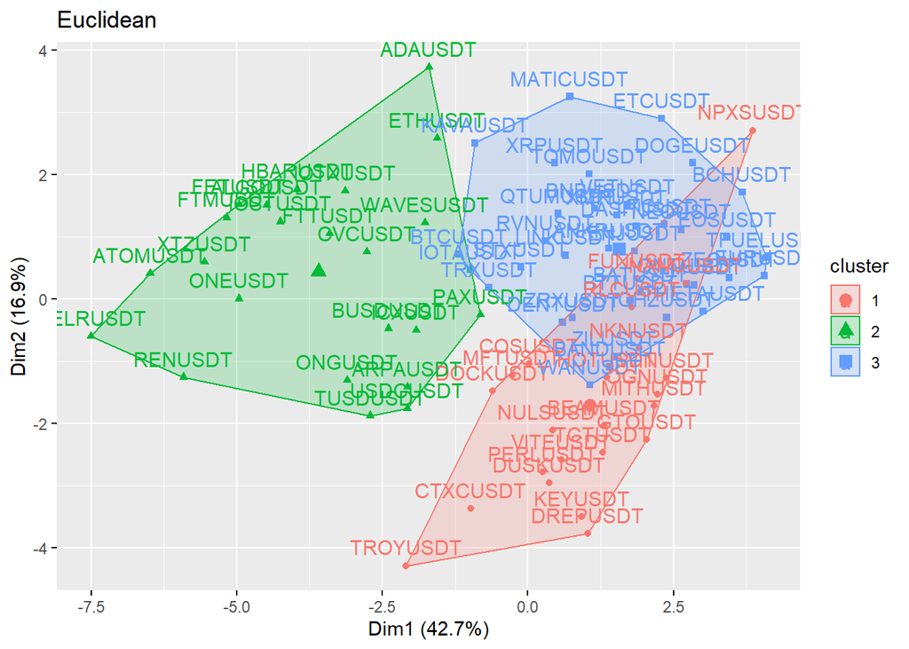

```r
# summary(data)

## Visualize the clusters
fviz_cluster(kmeans_crypto, data_x, main="Euclidean")
```

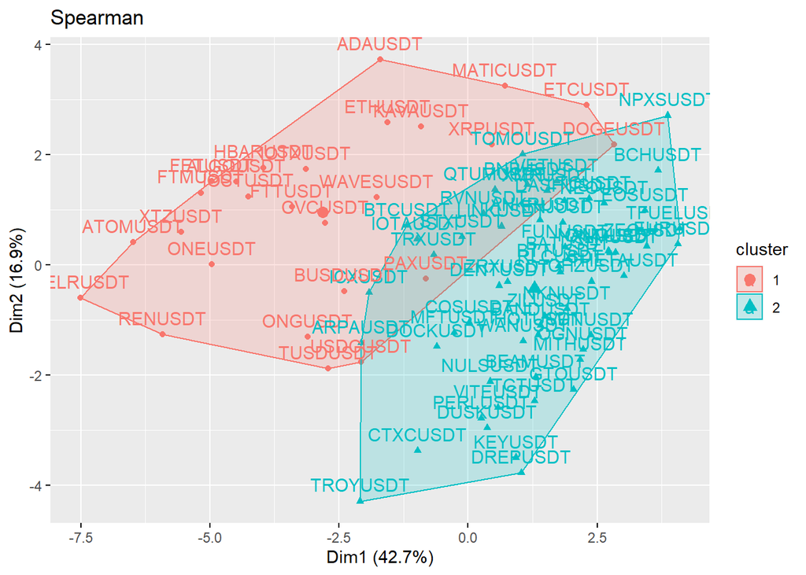

```r
## k= 2
Kmeans_crypto_2<-Kmeans(data_x_norm, centers=2 ,method = "spearman")
fviz_cluster(Kmeans_crypto_2, data_x, main="Spearman")
```

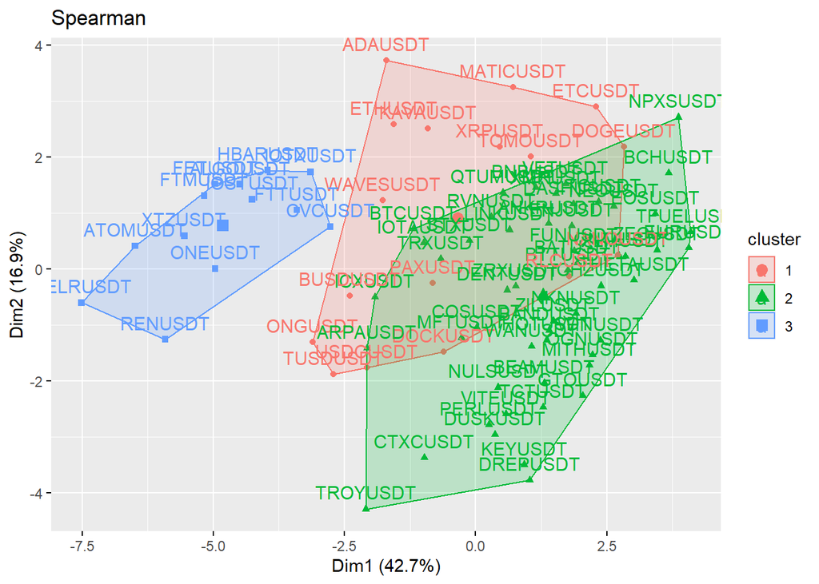

```r
## k= 3
Kmeans_crypto_3<-Kmeans(data_x_norm, centers=3 ,method = "spearman")
fviz_cluster(Kmeans_crypto_3, data_x, main="Spearman")
```

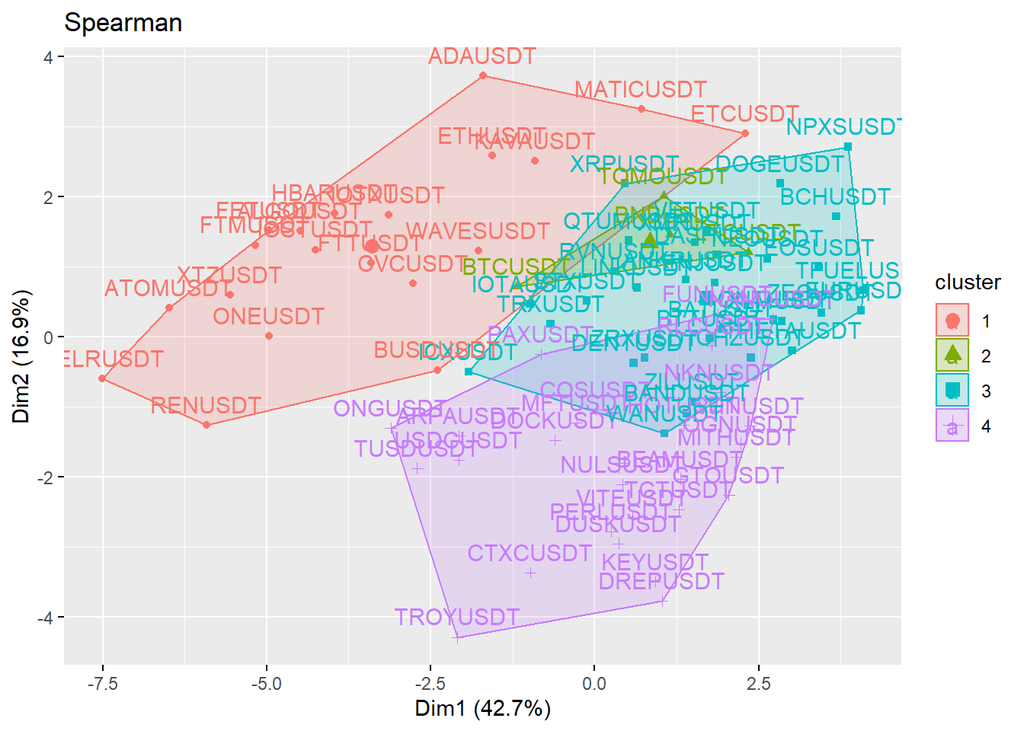

```r
## k=4
Kmeans_crypto_4<-Kmeans(data_x_norm, centers=4 ,method = "spearman")
fviz_cluster(Kmeans_crypto_4, data_x, main="Spearman")
```

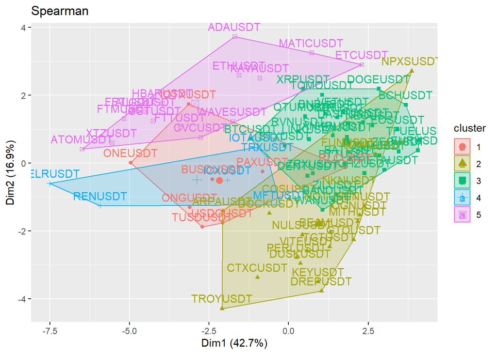

```r
## k=5
Kmeans_crypto_5<-Kmeans(data_x_norm, centers=5 ,method = "spearman")
fviz_cluster(Kmeans_crypto_5, data_x, main="Spearman")
```

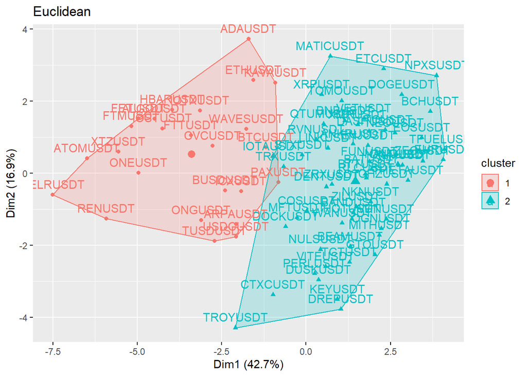

```r
## Euclidean
Kmeans_crypto_2_E<-Kmeans(data_x_norm, centers=2 ,method = "euclidean")
fviz_cluster(Kmeans_crypto_2_E, data_x, main="Euclidean")
```

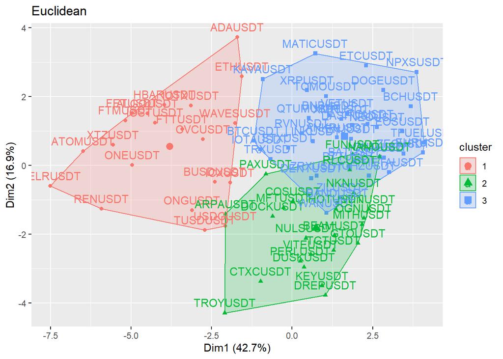

```r
## Euclidean
Kmeans_crypto_3_E<-Kmeans(data_x_norm, centers=3 ,method = "euclidean")
fviz_cluster(Kmeans_crypto_3_E, data_x, main="Euclidean")
```

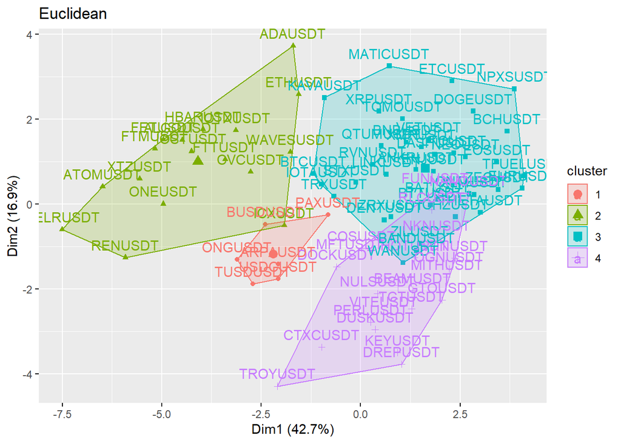

```r
## Euclidean
Kmeans_crypto_4_E<-Kmeans(data_x_norm, centers=4 ,method = "euclidean")
fviz_cluster(Kmeans_crypto_4_E, data_x, main="Euclidean")
```

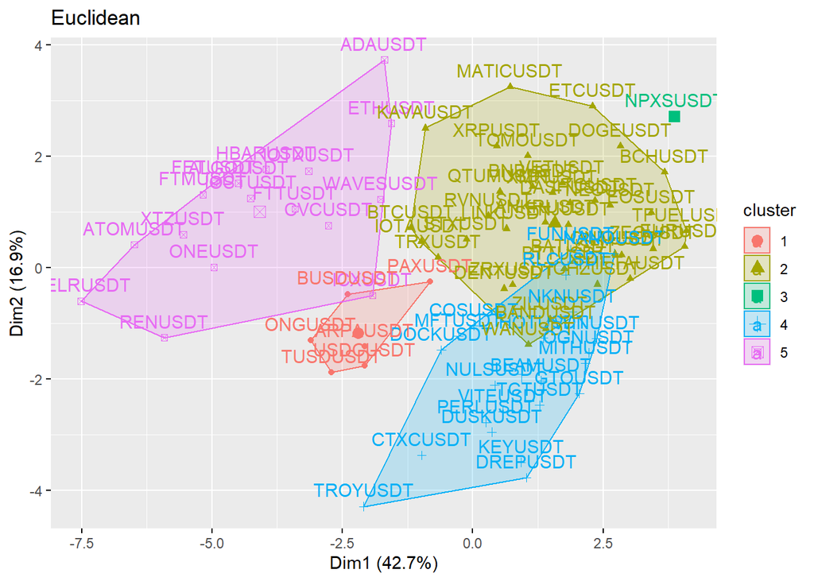

```r
## Euclidean
Kmeans_crypto_5_E<-Kmeans(data_x_norm, centers=5 ,method = "euclidean")
fviz_cluster(Kmeans_crypto_5_E, data_x, main="Euclidean")
```

## Predicting the new data(When k = 3)

Firstly, there is only a small datasets.

Secondly, some implied correlation ship between features.

```r
test_data
```

```
##           BBANDS_upperband BBANDS_middleband BBANDS_lowerband      DEMA
## OMGUSDT         0.84844462        0.79679651        0.6347080 1.0000000
## MTLUSDT         0.24839876        0.32570950        0.4708281 0.6863920
## COCOSUSDT       0.07316689        0.09581628        0.2186490 0.4503778
##                 EMA HT_TRENDLINE      macd macdsignal  macdhist       mfi
## OMGUSDT   0.8624313    1.0000000 0.9328355  0.8958187 0.6247112 0.4597395
## MTLUSDT   0.4931369    0.7296792 0.3537334  0.5051653 0.1922638 0.5156929
## COCOSUSDT 0.2085130    0.6746685 0.5224877  0.5196316 0.3083047 0.3056324
##               willr         ad     adosc       obv        atr      natr
## OMGUSDT   1.0000000 1.00000000 1.0000000 1.0000000 0.66505036 0.1029077
## MTLUSDT   0.2381246 0.51560654 0.3192943 0.7666801 0.24662145 0.1688476
## COCOSUSDT 0.2752296 0.06469343 0.5579290 0.8404704 0.04714609 0.1102522
##               trange Quotes_label
## OMGUSDT   0.45869003   Crazy rise
## MTLUSDT   0.06874019         Down
## COCOSUSDT 0.03155680         Down
```

```r
data.frame(kmeans_crypto$centers)
```

```
##   BBANDS_upperband BBANDS_middleband BBANDS_lowerband      DEMA       EMA
## 1       0.09383796         0.1226812        0.2576392 0.4858380 0.1947798
## 2       0.54734180         0.6477861        0.6805677 0.8165246 0.8447091
## 3       0.16002490         0.1833493        0.2307589 0.4242248 0.2800856
##   HT_TRENDLINE      macd macdsignal  macdhist       mfi     willr        ad
## 1    0.4743775 0.5105551  0.5358322 0.3863460 0.3689185 0.1837037 0.0429317
## 2    0.8793357 0.4632469  0.5597136 0.3299986 0.4130009 0.3784874 0.4633335
## 3    0.4109467 0.3630449  0.3610179 0.5469257 0.2244038 0.2827823 0.8449694
##       adosc       obv       atr      natr     trange
## 1 0.4821979 0.8321049 0.1440208 0.1649137 0.03709744
## 2 0.3314245 0.7882593 0.5110591 0.2030706 0.08603464
## 3 0.2957279 0.6457374 0.1372950 0.1248260 0.04254918
```

```r
# real label
test_data$Quotes_label
```

```
## [1] "Crazy rise" "Down"       "Down"
```

```r
euclidean <- function(a, b) sqrt(sum((a - b)^2))
```

```r
for (i in 1:nrow(test_data)) {
  print(i)
}
```

```
## [1] 1
## [1] 2
## [1] 3
```

## Hierarchical Clustering

Two method provide two different results.

Under the Euclidean distance, there are not obviously distinct clusterings , while the Manhattan method provide a much more distinct boundary on three parts.

```r
## Minkowski p=2 (Euclidean)
(HClust_Ward_Euc_N_crypto <- hclust(Dist_E, method = "average" ))
```

```
##
## Call:
## hclust(d = Dist_E, method = "average")
##
## Cluster method   : average
## Distance         : Euclidean
## Number of objects: 83
```

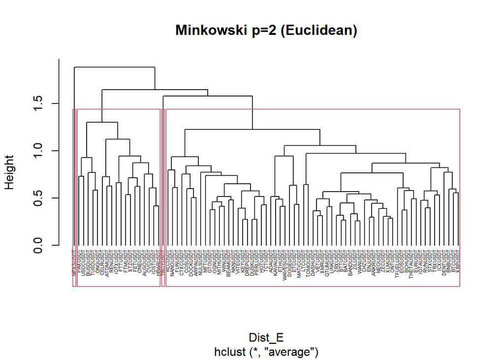

```r
plot(HClust_Ward_Euc_N_crypto, cex=0.9, hang=-1, main = "Minkowski p=2 (Euclidean)",cex=0.4)
rect.hclust(HClust_Ward_Euc_N_crypto, k=4)
```

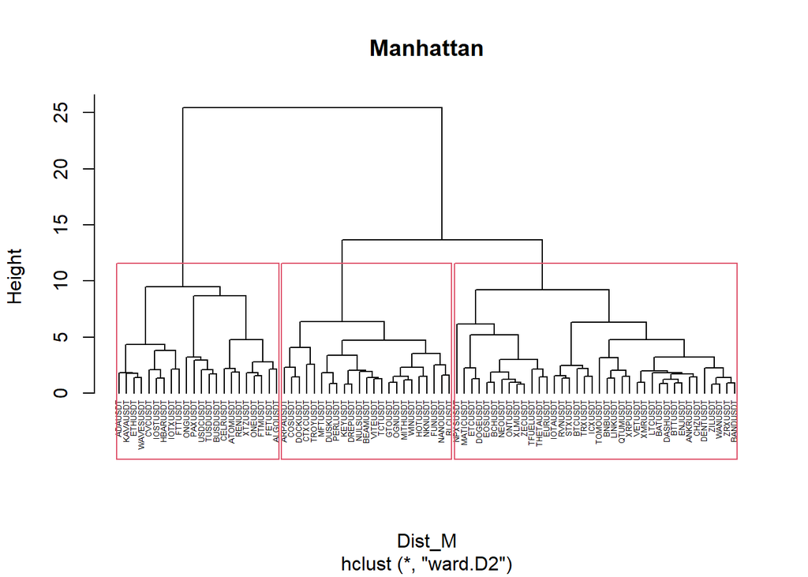

```r
## Using Man
HClust_Ward_Man_crypto <- hclust(Dist_M, method="ward.D2")
plot(HClust_Ward_Man_crypto, cex=.7, hang=-30,main = "Manhattan",cex=0.4)
rect.hclust(HClust_Ward_Man_crypto, k=3)
```

# Summary

The above clustering suggested that there was surely a clear clustering pattern, where the token had larger market value performed a similar market trend while other small market value tokens performed a different trend compared with the mainstream.